# Pitch Classification Model

Jonathan

```r
#Read in training set and load required packages

setwd("/nfs/home/jsl2985/z/Baseball")
library(dplyr)
library(ggplot2)
library(knitr)
library(pander)
library(nnet)
library(car)
library(gtools)

train <- read.csv("train.csv")

head(train)
```

```
##        last  first  mlbid   ab_id pitch_id start_speed        x0      z0
## 1 Rodriguez Aneury 444553 6887541 14245211     86.0684 -1.324120 6.25999
## 2   Teheran  Julio 527054 8228606 18022090     85.5755 -2.207150 5.26623
## 3   Jimenez Ubaldo 434622 7964438 17092031     85.8323 -0.619724 6.76257
## 4  Scherzer    Max 453286 8114960 17665697     84.9790 -3.145990 5.38198
## 5   Sanchez Anibal 434671 7808426 16599671     84.6510 -0.393495 5.82921
## 6     Leake   Mike 502190 8172331 17804454     86.0685 -1.439240 5.70329
##          px       pz   pfx_x pfx_z stand inning height count spinrateND
## 1 -0.758226 1.620140  -2.080 8.200     R      3     75   1-0    820.336
## 2  0.552364 1.317870  -4.859 6.240     L      1     74   0-2    805.150
## 3 -0.744407 1.592810  -3.347 2.010     L      1     76   1-2    321.815
## 4 -1.206540 2.909100 -11.663 2.753     L      5     75   1-1   1682.120
## 5 -1.191840 2.447090  -4.850 2.420     L      1     72   3-2    570.194
## 6 -0.537230 0.989718  -7.563 4.303     L      6     73   0-1   1014.050
##   spindirND       vxf      vzf    xangle  zangle pitch_type
## 1   195.898  0.538850 -14.6846 -0.269637 7.30824         CH
## 2   218.714  4.472940 -13.8151 -2.229840 6.85765         CH
## 3   260.962 -1.461970 -18.0544  0.726683 8.90224         CH
## 4   260.815  0.267519 -11.7972 -0.138128 6.06844         CH
## 5   254.682 -3.453470 -13.8986  1.746070 6.99429         CH
## 6   247.855 -0.645697 -16.2246  0.319280 7.97088         CH
```

```r
nrow(train)
```

```
## [1] 6920
```

First, I’ll look at some descriptive analysis of the training set.

## Summary Table

```r
train.table <- train %>%
  group_by(pitch_type) %>%
  dplyr::summarise (
    count = n(),
    avg.velo = mean(start_speed),
    max.velo = max(start_speed),
    min.velo = min(start_speed),
    avg.horiz = mean(pfx_x),
    avg.vert = mean(pfx_z),
    avg.spinaxis = mean(spindirND),
    avg.spinrate = mean(spinrateND),
    max.spinrate = max(spinrateND),
    min.spinrate = min(spinrateND)
)

pandoc.table(train.table, split.tables="INF", format="rmarkdown")
```

```
##
## ----------------------------------------------------------------------------------------------------------------------------------------
##  pitch_type   count   avg.velo   max.velo   min.velo   avg.horiz   avg.vert   avg.spinaxis   avg.spinrate   max.spinrate   min.spinrate
## ------------ ------- ---------- ---------- ---------- ----------- ---------- -------------- -------------- -------------- --------------
##      CH        640    83.76476   92.0192    70.9542    -6.811088  3.9882656    246.21779      1060.4376      3970.1800       26.3369
##
##      CS         6     74.41270   78.7188    68.8657    6.730000   -7.2530000    39.32690      1839.8133      3098.3600      1001.7500
##
##      CU        731    78.18420   88.6528    59.7745    5.968045   -6.0654350    47.45721      1802.3479      11577.6000      111.4040
##
##      EP         1     66.39090   66.3909    66.3909    -0.079000  2.2630000    145.47200       47.5259        47.5259        47.5259
##
##      FA       2481    92.97577   103.2430   73.9146    -4.492283  8.6858867    207.41108      1526.6293      6141.9000       96.3942
##
##      FC        425    89.22166   97.4590    79.6648    1.049652   5.8100565    157.66477       759.2988      3718.9500       41.6975
##
##      FO         2     87.61040   87.7135    87.5073    -5.260500  2.4385000    258.99850       541.8255       562.4690       521.1820
##
##      FS        149    84.67509   93.1235    76.2073    -5.876248  2.2634698    261.12474       804.4462      3016.8600       69.1576
##
##      KN        49     74.40201   82.2373    60.6498    1.456163   0.5693673    150.23922       662.4380      2786.4600       47.7411
##
##      SI       1430    91.78085   99.9966    75.0136    -8.133269  5.3702951    241.25288      1554.7652      15737.2000     -1664.1500
##
##      SL       1006    84.46982   94.1541    70.5247    2.777437   0.9276193    102.37087       551.5288      4974.0500       13.2439
## ----------------------------------------------------------------------------------------------------------------------------------------
```

It looks like there is a sinker with negative spin-rate, as well as some max spin-rates that seem outside the norm. I will correct these later. Everything else seems pretty standard in terms of velocity and movement.

## Velocity Descriptives

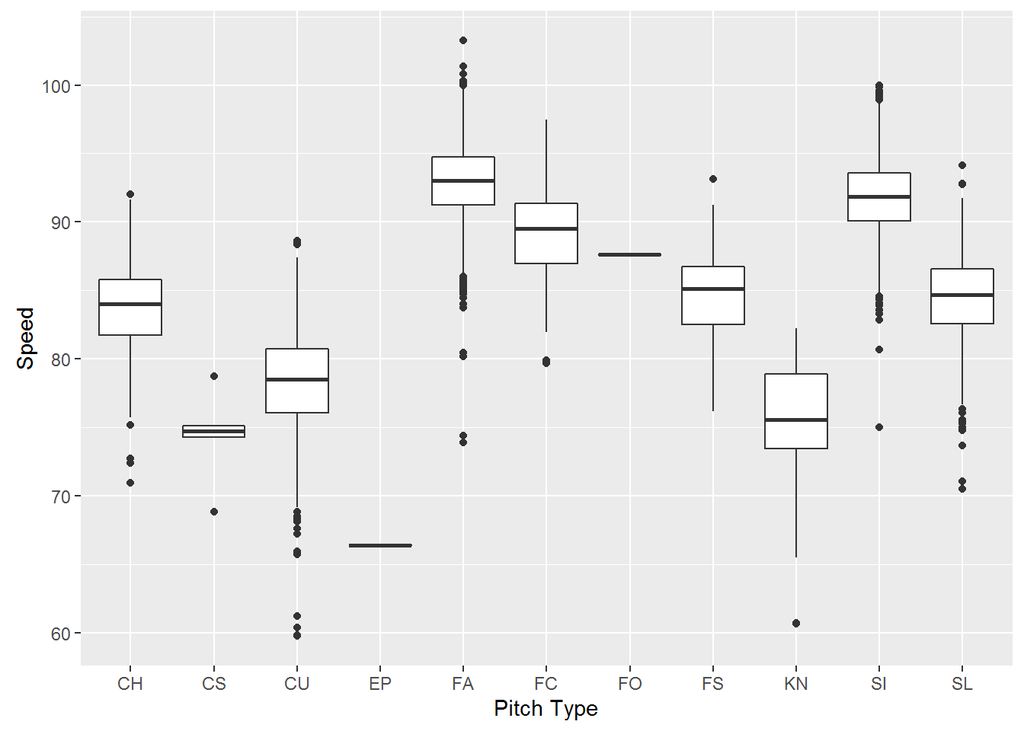

```r
ggplot(train, aes(x=pitch_type, y=start_speed)) + geom_boxplot() + labs(x="Pitch Type", y="Speed")
```

Here is a more detailed distribution of velocity by pitch type.

## Movement Descriptives

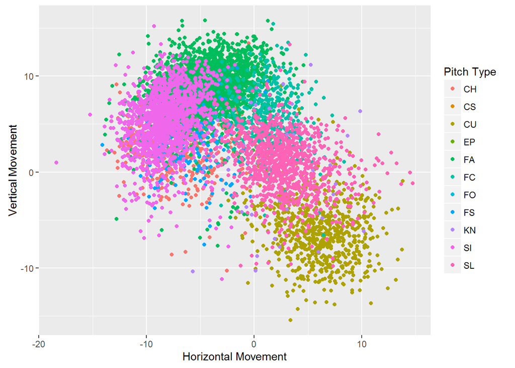

```r
ggplot(train, aes(x = pfx_x, y = pfx_z)) + geom_point(aes(color = pitch_type)) + labs(x="Horizontal Movement", y="Vertical Movement") + scale_colour_discrete(name="Pitch Type")
```

Based on the movement of pitches, with all cutters, sliders, and curveballs moving in direction opposite of sinkers and changeups, it seems the pitchers are all right-handed. This is confirmed scanning through the pitcher names.

This is a litle cluttered, so I’ll look at some of these types of pitches in separate graphs.

### Types of Fastballs

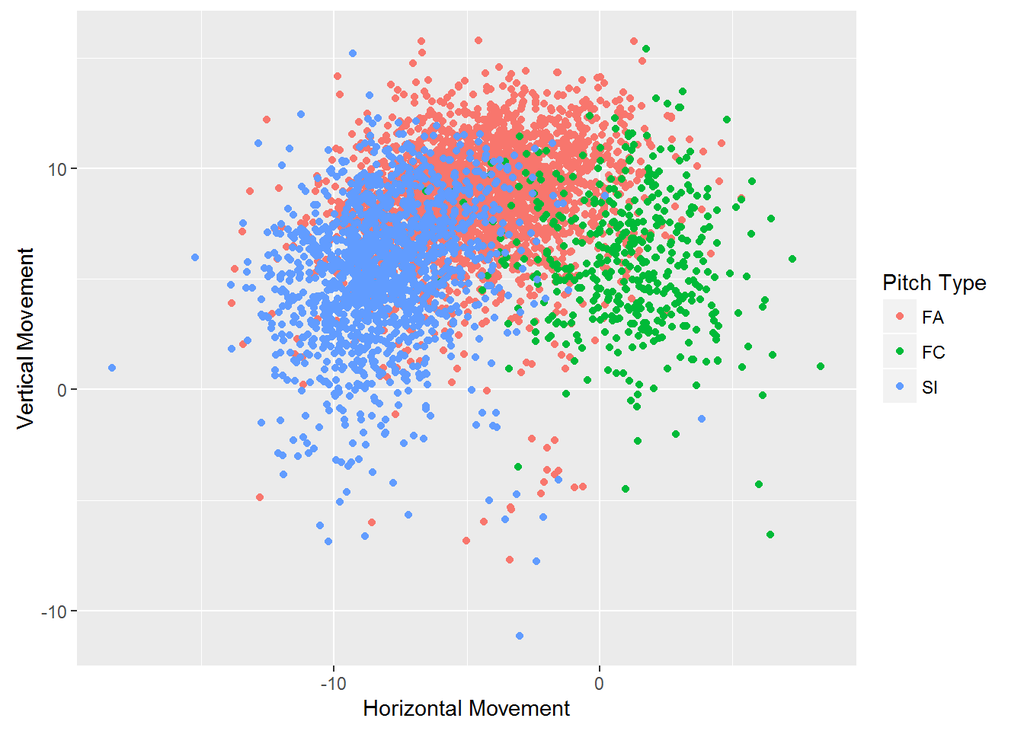

```r
train.fast <- subset(train, pitch_type == "FA" | pitch_type == "SI" | pitch_type == "FC")

ggplot(train.fast, aes(x = pfx_x, y = pfx_z)) + geom_point(aes(color = pitch_type)) + labs(x="Horizontal Movement", y="Vertical Movement") + scale_colour_discrete(name="Pitch Type")
```

There is more overlap between 4-seamers and sinkers than either have with cutters. 4-seamers have most rise on the high-end, but does overlap with Sinkers in the middle of each pitch’s distribution.

### Changeups vs. Sinkers

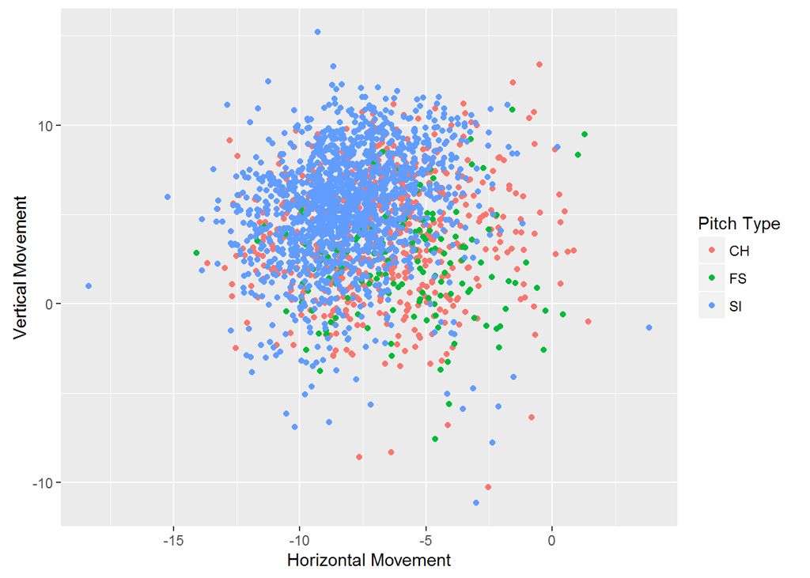

```r
train.SICHFS <- subset(train, pitch_type == "SI" | pitch_type == "CH" | pitch_type == "FS")

ggplot(train.SICHFS, aes(x = pfx_x, y = pfx_z)) + geom_point(aes(color = pitch_type)) + labs(x="Horizontal Movement", y="Vertical Movement") + scale_colour_discrete(name="Pitch Type")
```

Some changeups are more neutral than sinkers in terms of horizontal movement, but some changeups have just as much run as sinkers. Changeups quite similar to splitters in both directions.

### Breakingballs

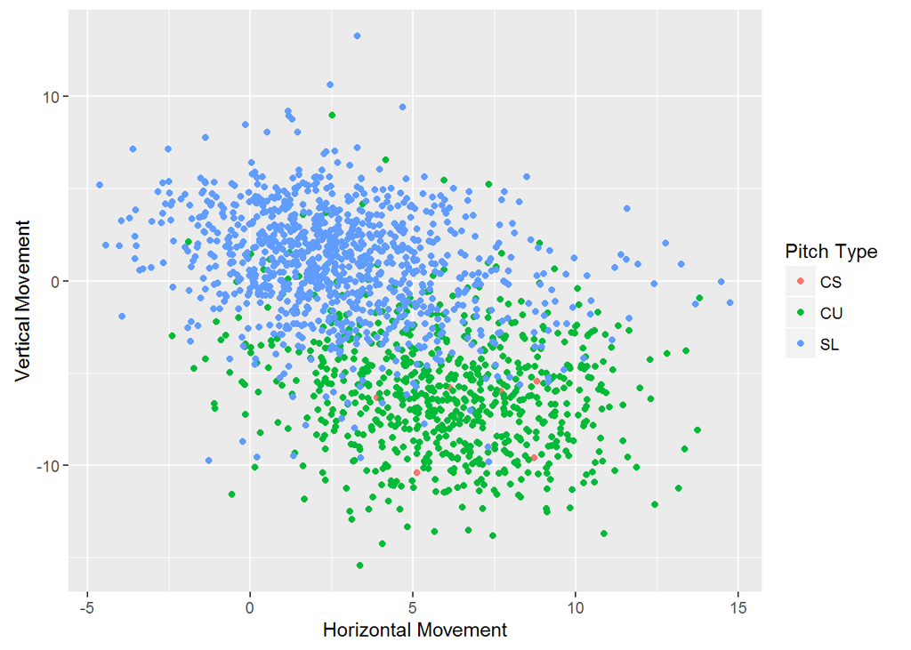

```r
train.bb <- subset(train, pitch_type == "SL" | pitch_type == "CU" | pitch_type == "CS")

ggplot(train.bb, aes(x = pfx_x, y = pfx_z)) + geom_point(aes(color = pitch_type)) + labs(x="Horizontal Movement", y="Vertical Movement") + scale_colour_discrete(name="Pitch Type")
```

Some outliers for sliders and curveballs moving into the other’ area’s distribution, but for the most part they are pretty distinct distinct.

# Spin Descriptives

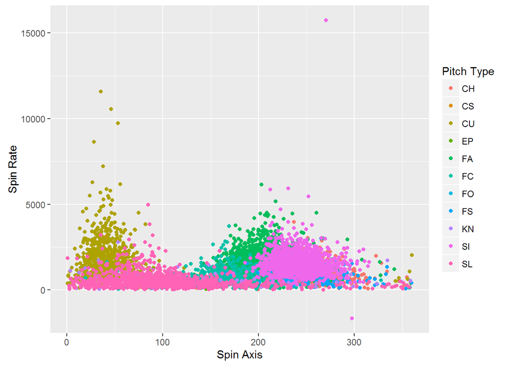

```r
ggplot(train, aes(x = spindirND, y = spinrateND)) + geom_point(aes(color = pitch_type)) + labs(x="Spin Axis", y="Spin Rate") + scale_colour_discrete(name="Pitch Type")
```

Seth Lugo set a Statcast record with 3498 rpm on Curveball.

A distribution chart of 4-seamers spin-rate per Mike Petriello at MLB.com doesn’t have any fastballs above the 2800 rpm bucket.

Can’t find info on max spin-rates on cutters, changeups, splitters, and sliders, but it would be strange for them to be above a 4-seam fastball.

I see that spin-rate on knuckleballs cannot be properly tracked by Statcast or Trackman, but do not see any ready fix.

To correct spin-rates:

Correct Curveballs above 3500 down to 3500.

Correct Fastballs above 2900 to 2900.

Correct cutters, changeups, splitters, sliders above 2900 to 2900.

Correct the one pitch with negative spin-rate to 0.

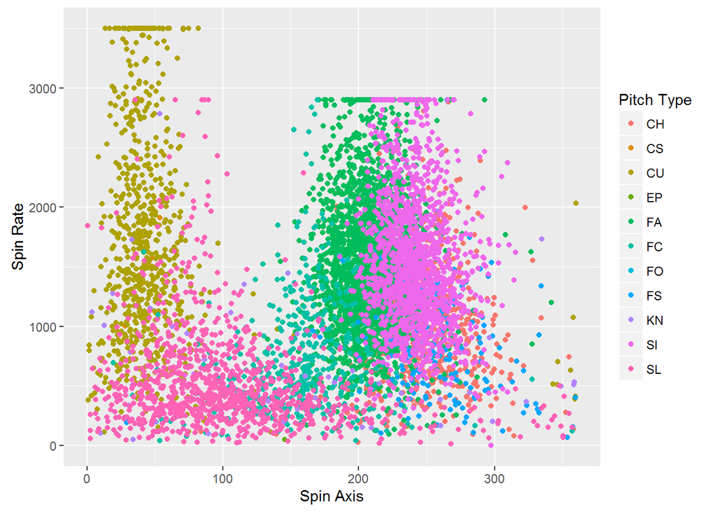

```r
train$spinrateND[train$spinrateND > 3500 & train$pitch_type == "CU"] <- 3500
train$spinrateND[train$spinrateND > 2900 & train$pitch_type != "CU"] <- 2900
train$spinrateND[train$spinrateND < 0] <- 0

ggplot(train, aes(x = spindirND, y = spinrateND)) + geom_point(aes(color = pitch_type)) + labs(x="Spin Axis", y="Spin Rate") + scale_colour_discrete(name="Pitch Type")
```

Despite cleaning spin-rate, there is a wide-range of spin-rates within pitch types. spin-axis seems to have cleaner dilineations, except for sliders. Since there is such variation within pitch types for spin-rate, this makes me believe it’s not the best indicator for determining pitch types, while spin-axis should be useful.

As with movement, I’ll look at some of these types of pitches in separate graphs.

### Types of Fastballs

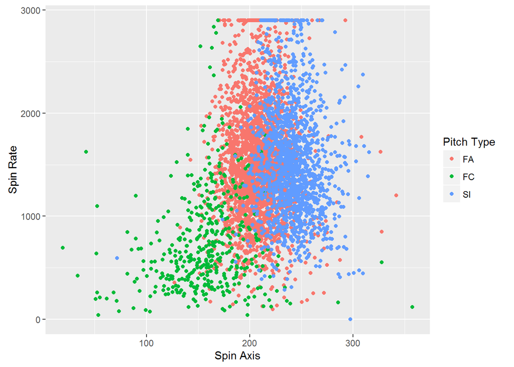

```r
train.fast <- subset(train, pitch_type == "FA" | pitch_type == "SI" | pitch_type == "FC")

ggplot(train.fast, aes(x = spindirND, y = spinrateND)) + geom_point(aes(color = pitch_type)) + labs(x="Spin Axis", y="Spin Rate") + scale_colour_discrete(name="Pitch Type")
```

Like with movement, there is more overlap between 4-seamers and Sinkers than either has with cutters. Cutters aren’t as tightly clustered around a single spin-axis, and also are generally lower in spin-rate.

### Changeups vs. Sinkers

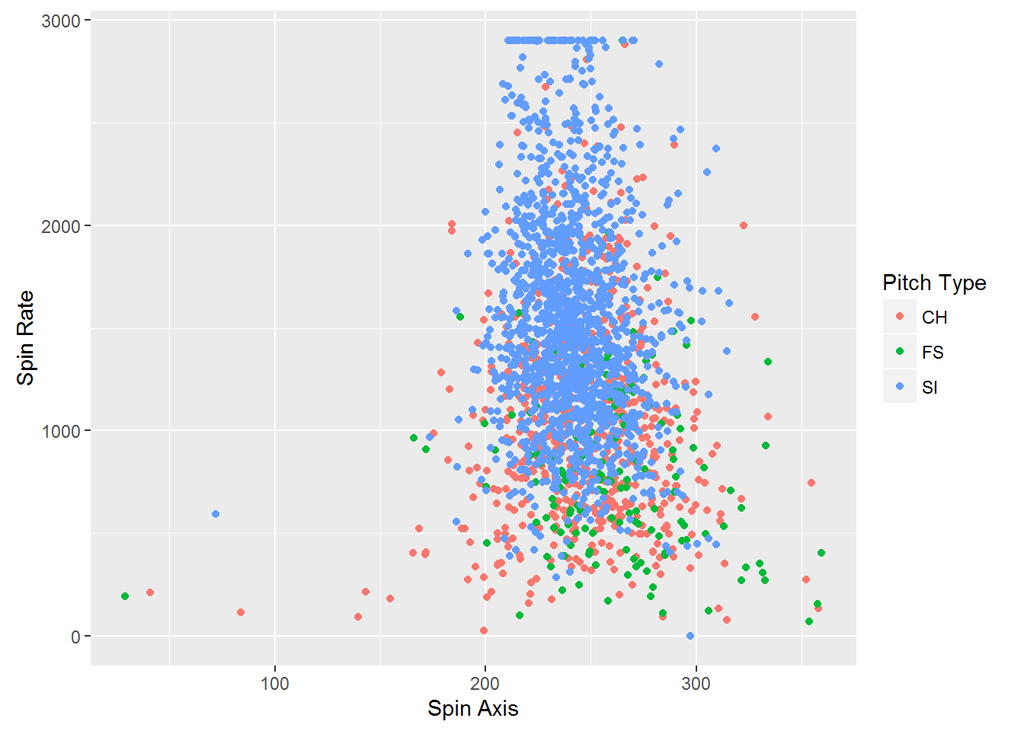

```r
train.SICHFS <- subset(train, pitch_type == "SI" | pitch_type == "CH" | pitch_type == "FS")

ggplot(train.SICHFS, aes(x = spindirND, y = spinrateND)) + geom_point(aes(color = pitch_type)) + labs(x="Spin Axis", y="Spin Rate") + scale_colour_discrete(name="Pitch Type")
```

Some changeups creep up into higher spin-rates, but at the low end there are not many sinkers. Again, not much distinction between changeups and splitters.

### Breakingballs

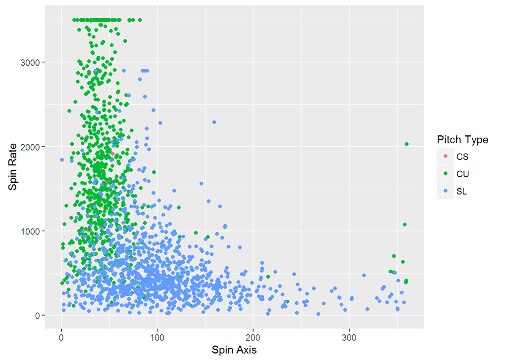

```r
train.bb <- subset(train, pitch_type == "SL" | pitch_type == "CU" | pitch_type == "CS")

ggplot(train.bb, aes(x = spindirND, y = spinrateND)) + geom_point(aes(color = pitch_type)) + labs(x="Spin Axis", y="Spin Rate") + scale_colour_discrete(name="Pitch Type")
```

Curveballs have higher spin-rates, and are tightly clustered around spin-axis.

# Release Point Descriptives

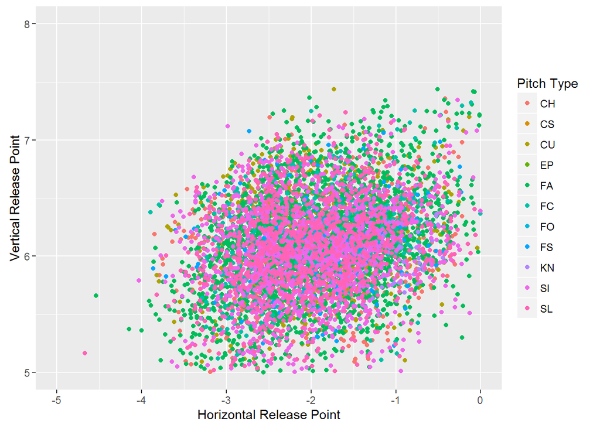

```r
ggplot(train, aes(x = x0, y = z0)) + geom_point(aes(color = pitch_type)) + labs(x="Horizontal Release Point", y="Vertical Release Point") + scale_colour_discrete(name="Pitch Type") + xlim(-5,0) + ylim(5,8)
```

Release Point is far too dependent on the pitcher to be predictive across multiple pitchers.

# Stand

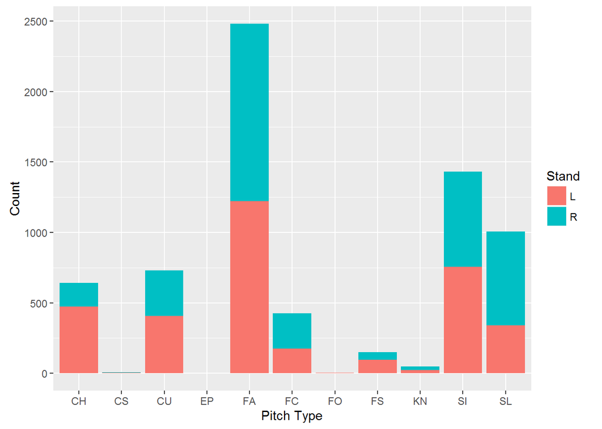

```r
ggplot(train, aes(factor(pitch_type))) + geom_bar(aes(fill=stand)) + labs(x="Pitch Type", y="Count") + scale_fill_discrete(name="Stand")
```

There are more changeups to LHB, and more sliders to RHB, as expected with this slate of right-handed pitchers, but probably not enough to be predictive.

# Count

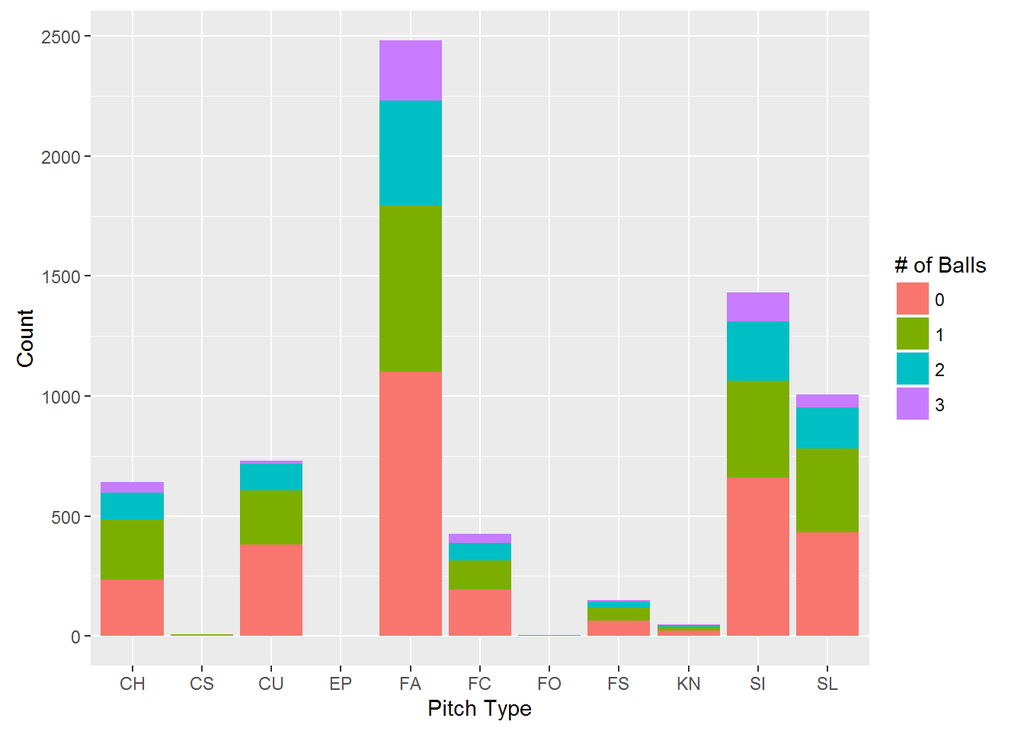

```r
train$balls <- substr(train$count, 1,1)
train$strikes <- substr(train$count, 3,3)

ggplot(train, aes(factor(pitch_type))) + geom_bar(aes(fill=balls)) + labs(x="Pitch Type", y="Count") + scale_fill_discrete(name="# of Balls")
```

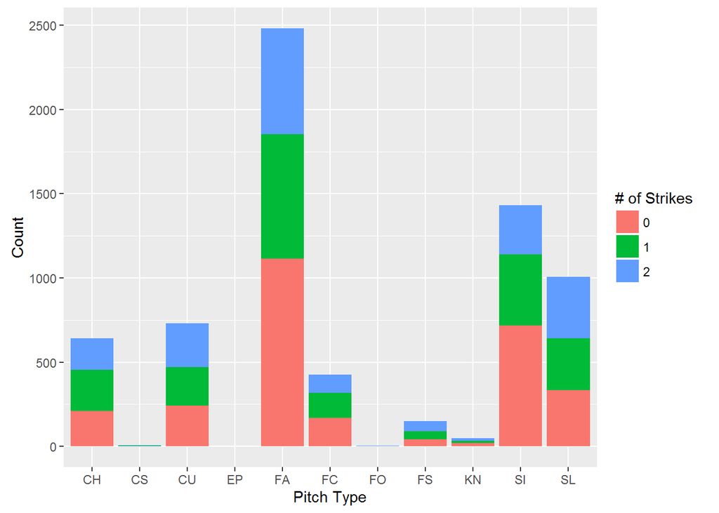

```r
ggplot(train, aes(factor(pitch_type))) + geom_bar(aes(fill=strikes)) + labs(x="Pitch Type", y="Count") + scale_fill_discrete(name="# of Strikes")
```

4-seamers and sinkers are more common in 3-ball counts, but I’m not sure if enough differentiation to be as predictive as hard pitch metrics.

# Location

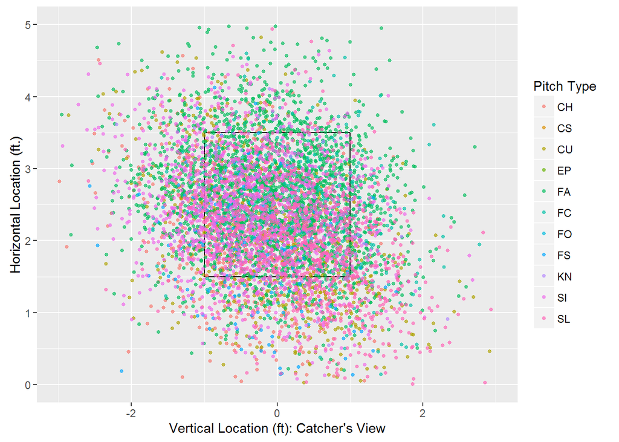

```r
q <- ggplot(train, aes(px, pz, color=pitch_type))
q <- q + scale_x_continuous(limits = c(-3,3)) + scale_y_continuous(limits = c(0,5)) + ggplot2::annotate("rect", xmin = -1, xmax = 1, ymin = 1.5, ymax = 3.5, color = "black", alpha = 0) + ylab("Horizontal Location (ft.)") + xlab("Vertical Location (ft): Catcher's View") + labs(color = "Pitch Type")
q <- q + geom_point(size=1, alpha = .65)
q
```

### Types of Fastballs

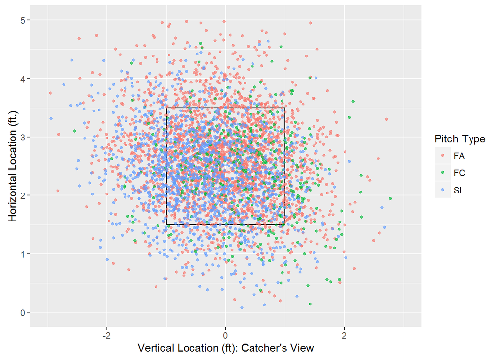

```r
q <- ggplot(train.fast, aes(px, pz, color=pitch_type))
q <- q + scale_x_continuous(limits = c(-3,3)) + scale_y_continuous(limits = c(0,5)) + ggplot2::annotate("rect", xmin = -1, xmax = 1, ymin = 1.5, ymax = 3.5, color = "black", alpha = 0) + ylab("Horizontal Location (ft.)") + xlab("Vertical Location (ft): Catcher's View") + labs(color = "Pitch Type")
q <- q + geom_point(size=1, alpha = .65)
q
```

### Breakingballs

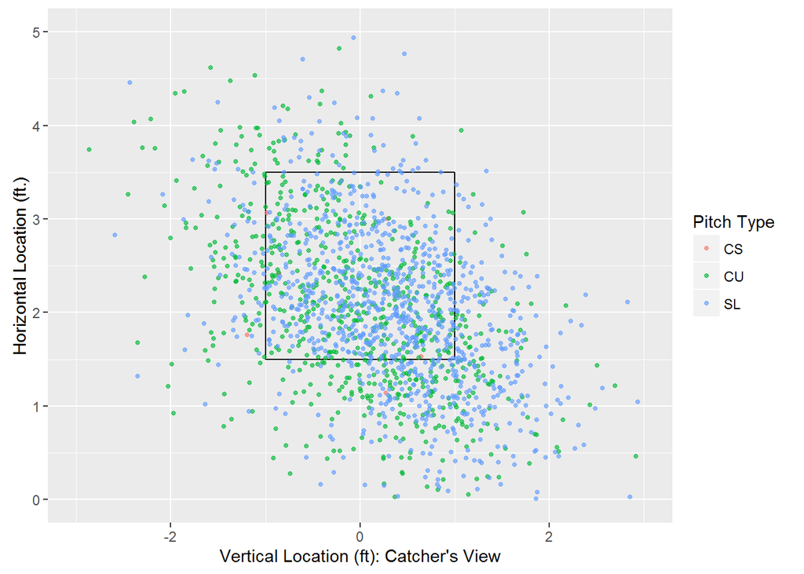

```r
q <- ggplot(train.bb, aes(px, pz, color=pitch_type))
q <- q + scale_x_continuous(limits = c(-3,3)) + scale_y_continuous(limits = c(0,5)) + ggplot2::annotate("rect", xmin = -1, xmax = 1, ymin = 1.5, ymax = 3.5, color = "black", alpha = 0) + ylab("Horizontal Location (ft.)") + xlab("Vertical Location (ft): Catcher's View") + labs(color = "Pitch Type")
q <- q + geom_point(size=1, alpha = .65)
q
```

Breakingballs (both sliders and curveballs) are located below the zone more frequently, but maybe not enough frequently to be predictive of pitch type.

# Multinomial Regression

With a categorical dependent variable with 11 different outcomes, I’ll use a multinomial regression model to predict the probabilities for each of the pitch types.

While the descriptive analysis leads me to believe that velocity, horizontal and vertical movement, and spin-axis will be the most predicive independent variables, I’ll first check if any of the other variables are significant.

```r
model <- multinom(pitch_type ~ start_speed + pfx_x + pfx_z + spinrateND + spindirND + px + pz + x0 + z0, train)
Anova(model)
```

```
## Analysis of Deviance Table (Type II tests)
##
## Response: pitch_type
##             LR Chisq Df Pr(>Chisq)
## start_speed  2430.25 10     <2e-16 ***
## pfx_x         637.90 10     <2e-16 ***
## pfx_z         110.77 10     <2e-16 ***
## spinrateND    -68.47 10     1.0000
## spindirND    -149.16 10     1.0000
## px            -87.73 10     1.0000
## pz            -70.34 10     1.0000
## x0             11.93 10     0.2901
## z0            -35.28 10     1.0000
## ---
## Signif. codes:  0 '***' 0.001 '**' 0.01 '*' 0.05 '.' 0.1 ' ' 1
```

In this kitchen-sink model, only velocity, horizontal movement, and vertical movement are statistically significant. I’ve tried various combinations of these independent variables as well, but the best combination is the 4 variables in my initial hypothesis. I’ve also tried quadratics of these 4 variables and interactions between them, but I think the following model works best.

```r
model <- multinom(pitch_type ~ start_speed  + pfx_x + pfx_z + spindirND, train)
Anova(model)
```

```
## Analysis of Deviance Table (Type II tests)
##
## Response: pitch_type
##             LR Chisq Df Pr(>Chisq)
## start_speed   3204.5 10  < 2.2e-16 ***
## pfx_x          879.0 10  < 2.2e-16 ***
## pfx_z          834.0 10  < 2.2e-16 ***
## spindirND       37.0 10  5.581e-05 ***
## ---
## Signif. codes:  0 '***' 0.001 '**' 0.01 '*' 0.05 '.' 0.1 ' ' 1
```

In this model, all 4 variables are highly significant. I’ll next look at the coefficients. With the multinomial model, each independent variable will have different coefficients for determining the probability for each pitch type.

```r
print(model)
```

```
## Call:
## multinom(formula = pitch_type ~ start_speed + pfx_x + pfx_z +
##     spindirND, data = train)
##
## Coefficients:
##    (Intercept) start_speed      pfx_x       pfx_z    spindirND
## CS   15.419601 -0.23829187  1.2240938 -0.80459693 -0.013828228
## CU    8.541315 -0.08062228  1.1895721 -0.73438898 -0.007441223
## EP   42.110531 -0.55620780  0.2379420 -0.15232656 -0.009220569
## FA  -90.803662  1.04388372  0.3334067  0.32414338 -0.002944901
## FC  -55.722154  0.67659573  1.0831937  0.05317701 -0.003137834
## FO  -45.895974  0.43832259  0.3021009  0.04157897  0.017597084
## FS  -12.564341  0.11678566  0.1767998 -0.06860101  0.010365809
## KN   33.859830 -0.40974769  0.7216174 -0.28804352 -0.002321498
## SI  -80.487365  0.88414400 -0.1226377  0.08279939  0.009104376
## SL  -19.333146  0.28375731  1.1169062 -0.24534477 -0.006686318
##
## Residual Deviance: 8425.573
## AIC: 8525.573
```

Next, I’ll back-fit the model to the training set to see what percentage of the pitches got correctly identified. I’ll base the prediction off the highest probability of the 11 probabilities calculated.

```r
probs <- predict(model, train, "probs")
probs <- as.data.frame(probs)

probs$maxprob <- apply(probs, 1, max)

probs$prediction <- ifelse(probs$maxprob == probs$CH, "CH", ifelse(probs$maxprob == probs$CS, "CS", ifelse(probs$maxprob == probs$CU, "CU", ifelse(probs$maxprob == probs$FA, "FA", ifelse(probs$maxprob == probs$FC, "FC", ifelse(probs$maxprob == probs$FO, "FO", ifelse(probs$maxprob == probs$FS, "FS", ifelse(probs$maxprob == probs$KN, "KN", ifelse(probs$maxprob == probs$SI, "SI", ifelse(probs$maxprob == probs$SL, "SL", "EP"))))))))))

train <- cbind(train, probs)

train$correct <- ifelse(train$pitch_type == train$prediction, 1, 0)

sum(train$correct)/nrow(train)
```

```
## [1] 0.7640173
```

The model predicted 76% of the pitches correctly. I’ll look at which were the common miscalculations.

```r
incorrect <- subset(train, correct == 0)

train.crosstab <- table(incorrect$pitch_type, incorrect$prediction)

train.crosstab
```

```
##
##       CH  CU  FA  FC  FS  KN  SI  SL
##   CH   0   2  16   6   3   1  65  22
##   CS   0   6   0   0   0   0   0   0
##   CU   1   0   0   0   2   6   0  88
##   EP   0   0   0   0   0   1   0   0
##   FA  18   0   0  50   2   0 278   9
##   FC   5   1 114   0   1   0   1 132
##   FO   0   0   0   0   0   0   2   0
##   FS  97   0   6   1   0   1  29   7
##   KN   8  10   0   0   0   0   0  11
##   SI  48   2 398   0   1   0   0   3
##   SL  26  66   9  72   3   0   3   0
```

Some common mistakes: Changeups identified as sinkers, presumably hard changeups getting classified as soft changeups. As seen in the descriptives, velocity is the main thing separating changeups from sinkers, as movement and spin were similar, but if you have a pitcher like Zack Greinke or Felix Hernandez who throw their changeups with only slight separations from their fastballs, it could register similarly to a soft-tossing sinkerballer.

Curveballs identified as sliders, cutters identified as sliders, sliders identified as curveballs or cutters. With these pitch types, it’s more of a gradient than a clean separation. Some pitchers throw hard sliders similar to cutters, others throw more of a slurve. A pitcher like Corey Kluber simply calls his pitch a breakingball.

4-seamers identified as sinkers, and vice-versa. As seen in the descriptives, there is some overlap in each of the independent variables.

Splitters identified as changeups. This could be the hardest distinction given the lack of separation seen in the descriptives.

# 2-Step Multinomial Regression

To try to improve the model, I’ll try to do the model in two-steps. I’ll include cutters with the breakingballs given some of the common mistakes, although it could reasonably fit with the fastballs as well. In Part 1, I’ll identify the pitch as “Straight”, “Breaking”, and knuckleballs, eephuses, and pitch-outs. I think the independent variables could be more predictive with fewer outcomes to determine. For example, determining a cutter from a slider could be easier when the model doesn’t have to also evaluate if the cutter is a 4-seamer, changeup, or other pitch.

## Part 1

```r
train <- read.csv("train.csv")
train$spinrateND[train$spinrateND > 3500 & train$pitch_type == "CU"] <- 3500
train$spinrateND[train$spinrateND > 2900 & train$pitch_type != "CU"] <- 2900
train$spinrateND[train$spinrateND < 0] <- 0

train$pitch_type2[train$pitch_type == "FA" | train$pitch_type == "SI" | train$pitch_type == "CH" | train$pitch_type == "FS"] <- "Straight"
train$pitch_type2[train$pitch_type == "CU" | train$pitch_type == "SL" | train$pitch_type == "FC" | train$pitch_type == "CS"] <- "Breaking"
train$pitch_type2[train$pitch_type == "KN"] <- "KN"
train$pitch_type2[train$pitch_type == "EP"] <- "EP"
train$pitch_type2[train$pitch_type == "FO"] <- "FO"

model <- multinom(pitch_type2 ~ start_speed + pfx_x + pfx_z + spindirND, train)
Anova(model)
```

```
## Analysis of Deviance Table (Type II tests)
##
## Response: pitch_type2
##             LR Chisq Df Pr(>Chisq)
## start_speed   295.33  4  < 2.2e-16 ***
## pfx_x         558.75  4  < 2.2e-16 ***
## pfx_z         244.81  4  < 2.2e-16 ***
## spindirND      49.95  4  3.695e-10 ***
## ---
## Signif. codes:  0 '***' 0.001 '**' 0.01 '*' 0.05 '.' 0.1 ' ' 1
```

```r
print(model)
```

```
## Call:
## multinom(formula = pitch_type2 ~ start_speed + pfx_x + pfx_z +
##     spindirND, data = train)
##
## Coefficients:
##          (Intercept) start_speed      pfx_x     pfx_z   spindirND
## EP          81.32766  -1.2444482 -0.8829618 0.5673519 0.003682577
## FO         -21.54827   0.0987965 -0.6061936 0.1153590 0.023636129
## KN          26.89756  -0.3861537 -0.2314898 0.1539725 0.005982540
## Straight   -16.91652   0.1389454 -0.7897808 0.2990391 0.013407956
##
## Residual Deviance: 1781.111
## AIC: 1821.111
```

```r
probs <- predict(model, train, "probs")
probs <- as.data.frame(probs)

probs$maxprob <- apply(probs, 1, max)

probs$prediction <- ifelse(probs$maxprob == probs$Straight, "Straight", ifelse(probs$maxprob == probs$Breaking, "Breaking", ifelse(probs$maxprob == probs$FO, "FO", ifelse(probs$maxprob == probs$KN, "KN", "EP"))))

train <- cbind(train, probs)

train$correct <- ifelse(train$pitch_type2 == train$prediction, 1, 0)

sum(train$correct)/nrow(train)
```

```
## [1] 0.9507225
```

Back-fitting the model after Part 1, it correctly identifies 95% of the pitches as straight, breaking, or one of the other pitch types.

## Separate

```r
train.straight <- subset(train, pitch_type2 == "Straight")
train.breaking <- subset(train, pitch_type2 == "Breaking")
train.other <- subset(train, pitch_type == "KN" | pitch_type == "FO" | pitch_type == "EP")
```

## Part 2A: Straight Pitches

```r
model.straight <- multinom(pitch_type ~ start_speed + pfx_x + pfx_z + spindirND, train.straight)
Anova(model.straight)
```

```
## Analysis of Deviance Table (Type II tests)
##
## Response: pitch_type
##             LR Chisq Df Pr(>Chisq)
## start_speed  2436.96  3  < 2.2e-16 ***
## pfx_x         111.03  3  < 2.2e-16 ***
## pfx_z          30.72  3  9.759e-07 ***
## spindirND      39.84  3  1.151e-08 ***
## ---
## Signif. codes:  0 '***' 0.001 '**' 0.01 '*' 0.05 '.' 0.1 ' ' 1
```

```r
print(model.straight)
```

```
## Call:
## multinom(formula = pitch_type ~ start_speed + pfx_x + pfx_z +
##     spindirND, data = train.straight)
##
## Coefficients:
##    (Intercept) start_speed      pfx_x       pfx_z    spindirND
## FA   -88.48150   1.0788940  0.1789317  0.19519553 -0.027507934
## FS   -13.61493   0.1194845  0.1821757 -0.03619372  0.013337244
## SI   -83.45423   0.9198195 -0.1660652  0.06810978  0.007337797
##
## Residual Deviance: 4860.89
## AIC: 4890.89
```

```r
probs.straight <- predict(model.straight, train.straight, "probs")
probs.straight <- as.data.frame(probs.straight)

probs.straight$maxprob.straight <- apply(probs.straight, 1, max)

probs.straight$prediction.straight <- ifelse(probs.straight$maxprob.straight == probs.straight$FA, "FA", ifelse(probs.straight$maxprob.straight == probs.straight$SI, "SI", ifelse(probs.straight$maxprob.straight == probs.straight$CH, "CH", "FS")))

train.straight <- cbind(train.straight, probs.straight)

train.straight$correct.straight <- ifelse(train.straight$pitch_type == train.straight$prediction.straight, 1, 0)

sum(train.straight$correct.straight)/nrow(train.straight)
```

```
## [1] 0.7902128
```

All 4 variables are statisically significant when separating out straight pitches. When back-fitting, 79% of straight pitches are correctly identified.

## Part 2B: Breaking Pitches

```r
model.breaking <- multinom(pitch_type ~ start_speed + pfx_x + pfx_z + spindirND, train.breaking)
Anova(model.breaking)
```

```
## Analysis of Deviance Table (Type II tests)
##
## Response: pitch_type
##             LR Chisq Df Pr(>Chisq)
## start_speed   338.88  3     <2e-16 ***
## pfx_x           5.06  3     0.1675
## pfx_z         472.60  3     <2e-16 ***
## spindirND       2.39  3     0.4961
## ---
## Signif. codes:  0 '***' 0.001 '**' 0.01 '*' 0.05 '.' 0.1 ' ' 1
```

```r
print(model.breaking)
```

```
## Call:
## multinom(formula = pitch_type ~ start_speed + pfx_x + pfx_z +
##     spindirND, data = train.breaking)
##
## Coefficients:
##    (Intercept) start_speed      pfx_x      pfx_z  spindirND
## CU   -9.960694   0.1674796 -0.2720215 -0.1341866 0.06845150
## FC  -69.850237   0.8748747 -0.3779391  0.8103297 0.06962894
## SL  -38.289143   0.5394422 -0.3252362  0.4084885 0.06711721
##
## Residual Deviance: 1854.29
## AIC: 1884.29
```

```r
probs.breaking <- predict(model.breaking, train.breaking, "probs")
probs.breaking <- as.data.frame(probs.breaking)

probs.breaking$maxprob.breaking <- apply(probs.breaking, 1, max)

probs.breaking$prediction.breaking <- ifelse(probs.breaking$maxprob.breaking == probs.breaking$CU, "CU", ifelse(probs.breaking$maxprob.breaking == probs.breaking$SL, "SL", ifelse(probs.breaking$maxprob.breaking == probs.breaking$FC, "FC", "CS")))

train.breaking <- cbind(train.breaking, probs.breaking)

train.breaking$correct.breaking <- ifelse(train.breaking$pitch_type == train.breaking$prediction.breaking, 1, 0)

sum(train.breaking$correct.breaking)/nrow(train.breaking)
```

```
## [1] 0.8274908
```

Only velocity and vertical movement are statistically significant when determining pitch types within breaking pitches. When back-fitting, 83% of breaking pitches are correctly identified.

```r
(sum(train.breaking$correct.breaking) + sum(train.straight$correct.straight) + sum(train.other$correct))/nrow(train)
```

```
## [1] 0.7978324
```

Overall, 80% of pitches are back-fitted correctly, a slight improvement, but many of the harder distinctions remain.

# Apply to Test Set

I’ll now apply the two-part model to the test dataset.

```r
test <- read.csv("test.csv")

#Part 1

probs <- predict(model, test, "probs")
probs <- as.data.frame(probs)

probs$maxprob <- apply(probs, 1, max)

probs$prediction <- ifelse(probs$maxprob == probs$Straight, "Straight", ifelse(probs$maxprob == probs$Breaking, "Breaking", ifelse(probs$maxprob == probs$FO, "FO", ifelse(probs$maxprob == probs$KN, "KN", "EP"))))

test <- cbind(test, probs)

#Separate

test.straight <- subset(test, prediction == "Straight")
test.breaking <- subset(test, prediction == "Breaking")
test.other <- subset(test, prediction == "KN" | prediction == "FO" | prediction == "EP")

#Part 2A

probs.straight <- predict(model.straight, test.straight, "probs")
probs.straight <- as.data.frame(probs.straight)

probs.straight$maxprob.straight <- apply(probs.straight, 1, max)

probs.straight$prediction.straight <- ifelse(probs.straight$maxprob.straight == probs.straight$FA, "FA", ifelse(probs.straight$maxprob.straight == probs.straight$SI, "SI", ifelse(probs.straight$maxprob.straight == probs.straight$CH, "CH", "FS")))

test.straight <- cbind(test.straight, probs.straight)

#Part 2B

probs.breaking <- predict(model.breaking, test.breaking, "probs")
probs.breaking <- as.data.frame(probs.breaking)

probs.breaking$maxprob.breaking <- apply(probs.breaking, 1, max)

probs.breaking$prediction.breaking <- ifelse(probs.breaking$maxprob.breaking == probs.breaking$CU, "CU", ifelse(probs.breaking$maxprob.breaking == probs.breaking$SL, "SL", ifelse(probs.breaking$maxprob.breaking == probs.breaking$FC, "FC", "CS")))

#Combine

test.breaking <- cbind(test.breaking, probs.breaking)

test.2 <- smartbind(test.straight, test.breaking, test.other)

test.2$prediction2[test.2$prediction.straight == "FA"] <- "FA"
test.2$prediction2[test.2$prediction.straight == "SI"] <- "SI"
test.2$prediction2[test.2$prediction.straight == "CH"] <- "CH"
test.2$prediction2[test.2$prediction.straight == "FS"] <- "FS"
test.2$prediction2[test.2$prediction.breaking == "FC"] <- "FC"
test.2$prediction2[test.2$prediction.breaking == "SL"] <- "SL"
test.2$prediction2[test.2$prediction.breaking == "CU"] <- "CU"
test.2$prediction2[test.2$prediction.breaking == "CS"] <- "CS"
test.2$prediction2[test.2$prediction == "KN"] <- "KN"
test.2$prediction2[test.2$prediction == "FO"] <- "FO"
test.2$prediction2[test.2$prediction == "EP"] <- "EP"

test.2 <- subset(test.2, select= -c(Breaking, EP, FO, KN, Straight, maxprob, prediction, CH, FA, FS, SI, maxprob.straight, prediction.straight, CS, CU, FC, SL, maxprob.breaking, prediction.breaking))
```

# Descriptives for Test Set

As a sanity check, I’ll look at some of the more helpful descriptive tables and analysis for the test set.

## Summary Table

```r
test.table <- test.2 %>%
  group_by(prediction2) %>%
  dplyr::summarise (
    count = n(),
    avg.velo = mean(start_speed),
    max.velo = max(start_speed),
    min.velo = min(start_speed),
    avg.horiz = mean(pfx_x),
    avg.vert = mean(pfx_z),
    avg.spinaxis = mean(spindirND),
    avg.spinrate = mean(spinrateND),
    max.spinrate = max(spinrateND),
    min.spinrate = min(spinrateND)
)

pandoc.table(test.table, split.tables="INF", format="rmarkdown")
```

```
##
## -----------------------------------------------------------------------------------------------------------------------------------------
##  prediction2   count   avg.velo   max.velo   min.velo   avg.horiz   avg.vert   avg.spinaxis   avg.spinrate   max.spinrate   min.spinrate
## ------------- ------- ---------- ---------- ---------- ----------- ---------- -------------- -------------- -------------- --------------
##      CH         345    83.47865   87.4977    75.2672    -6.666258  3.8457594    248.82291      1012.7873       3106.720       84.39400
##
##      CU         359    78.20181   86.3187    67.0308    6.195563   -6.1997967    46.77985      1878.4255      26444.800      183.38400
##
##      EP          1     66.08880   66.0888    66.0888    -2.148000  10.9340000   190.08200      1206.9200       1206.920      1206.92000
##
##      FA        1295    92.98162   99.9733    85.5423    -4.303846  9.0174170    205.28601      1517.2621       6036.900      132.69900
##
##      FC         148    90.14899   96.5112    84.2561    1.854953   6.5941824    154.13390       835.0638       3000.730      118.91300
##
##      FS          5     86.74892   88.4261    84.8123    -3.235200  -1.9482000   322.63300       484.0166       1027.410       57.46010
##
##      KN          5     68.14098   74.5710    59.3040    -0.426400  1.3828000    177.48130       388.3682       677.401       112.77900
##
##      SI         712    91.70598   98.4938    86.3461    -8.818166  4.5970309    248.36182      1573.1743       9859.870       89.54150
##
##      SL         543    84.16940   92.4774    73.7298    3.040087   0.9045212     95.31346       528.4625       3016.740       8.95065
## -----------------------------------------------------------------------------------------------------------------------------------------
```

## Velocity Descriptives

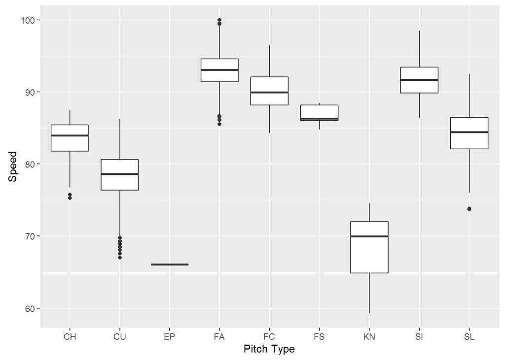

```r
ggplot(test.2, aes(x=prediction2, y=start_speed)) + geom_boxplot() + labs(x="Pitch Type", y="Speed")
```

## Movement Descriptives

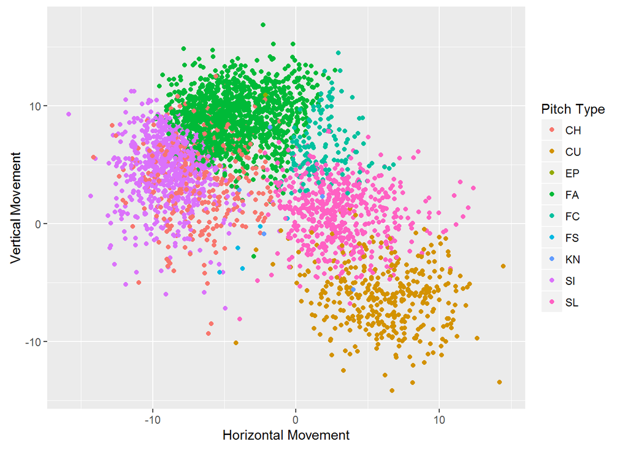

```r
ggplot(test.2, aes(x = pfx_x, y = pfx_z)) + geom_point(aes(color = prediction2)) + labs(x="Horizontal Movement", y="Vertical Movement") + scale_colour_discrete(name="Pitch Type")
```

## Spin Descriptives

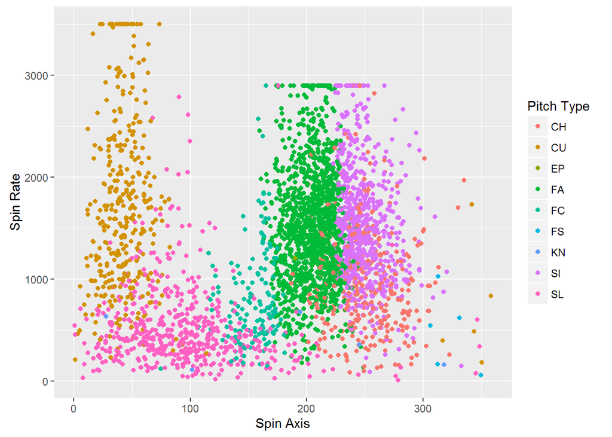

```r
test.2$spinrateND[test.2$spinrateND > 3500 & test.2$prediction2 == "CU"] <- 3500
test.2$spinrateND[test.2$spinrateND > 2900 & test.2$prediction2 != "CU"] <- 2900
test.2$spinrateND[test.2$spinrateND < 0] <- 0

ggplot(test.2, aes(x = spindirND, y = spinrateND)) + geom_point(aes(color = prediction2)) + labs(x="Spin Axis", y="Spin Rate") + scale_colour_discrete(name="Pitch Type")
```

Most of this checks out to me. The main thing that stands out to me is that the model only predicted 5 splitters, likely classifying them as changeups, but I have not determined any independent variables that really separates the two pitch types. The descriptive graphs show the pitches identified as splitters have a different spin-axis than those identified as changeups, which might be true in the training graph, but the training graph has a lot more noise.

# Export Test Set

```r
write.csv(test.2, "test.2.csv")
```